# Advanced Mixed Linear Model Data Visualization Dashboard

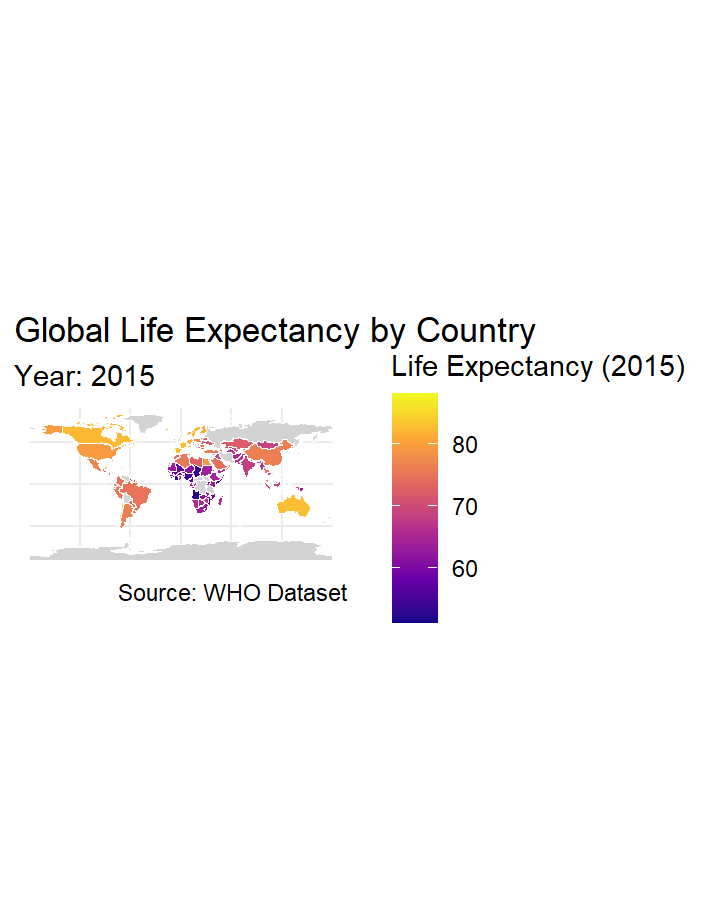

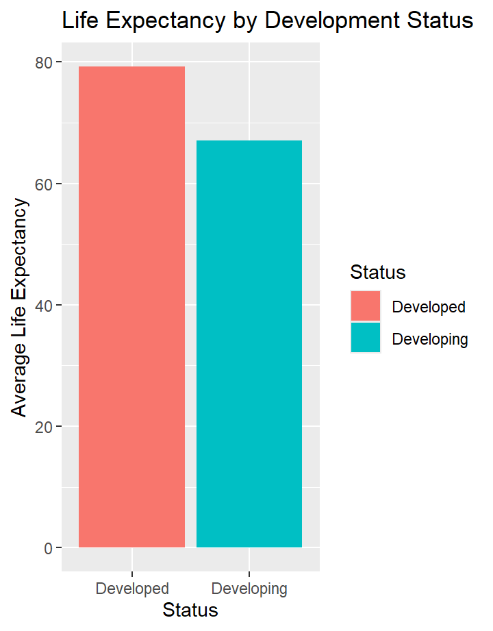

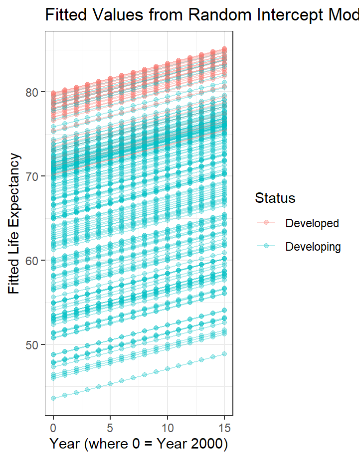

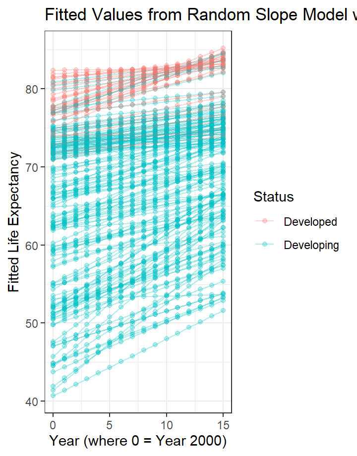

# Introduction

The data-set related to life expectancy, health factors for 193 countries has been collected from the same WHO data repository website and its corresponding economic data was collected from United Nation website. It has been observed that in the past 15 years , there has been a huge development in health sector resulting in improvement of human mortality rates especially in the developing nations in comparison to the past 30 years. Therefore, in this project we have considered data from year 2000-2015 for 193 countries for further analysis.

### Acknowledgment

The data are accessible online from Kaggle Platform. This data was collected from WHO and United Nations website with the help of Deeksha Russell and Duan Wang. The link : https://www.kaggle.com/datasets/kumarajarshi/life-expectancy-who.

### Objective :

A Data set used 2 level, Status = Developed and Developing Countries, Country = 193 Country, Year = 2000 - 2015, Life Expectancy : in Numerical as an Outcome.

**Aim:** To compare the performance of two linear mixed-effects models: one incorporating only a random intercept and the other including both a random intercept and a random slope. The objective is to determine whether allowing slopes to vary across groups e.g countries improves model fit and better captures the variability in the outcome variable.

# Global Life Expectancy by Country

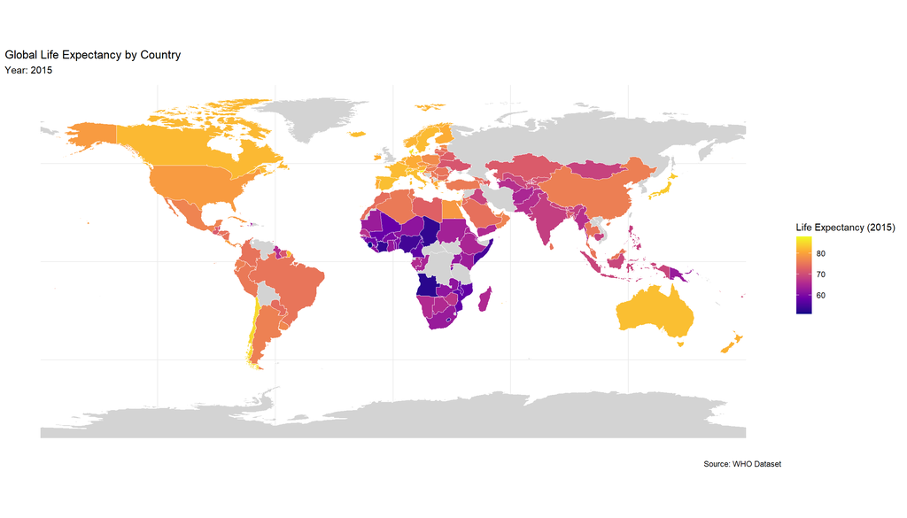

#### Comment

The choropleth map illustrates global life expectancy in 2015, with lighter shades indicating higher averages. Countries like those in North America, Western Europe, Japan, and Australia typically exceed 75 years, while many in sub-Saharan Africa fall below 60. Southeast Asia and Latin America show moderate levels, reflecting improvements in healthcare and development. The map underscores global disparities and the need for continued public health efforts to promote health equity.

# Life Expectancy for Asean

### ( Malaysia, Singapopre, Thailand, Indonesia)

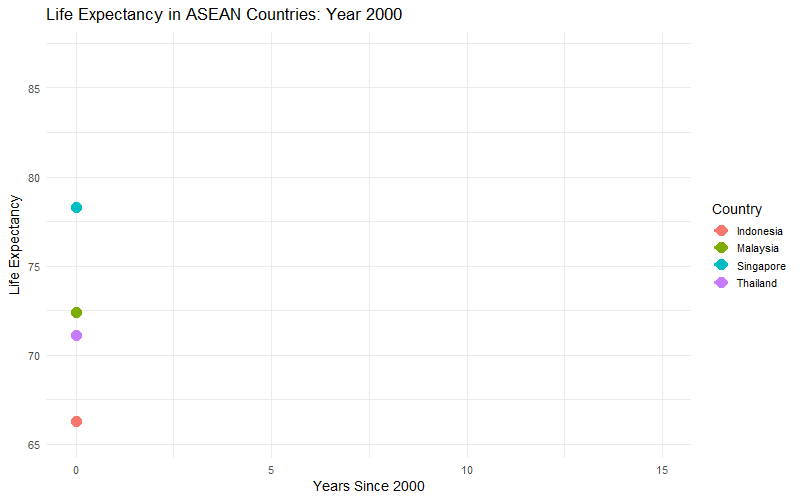

# Life Expectancy Trends

### Life Expectancy Trends with Group Mean Averages According to Status (Developed and Developing)

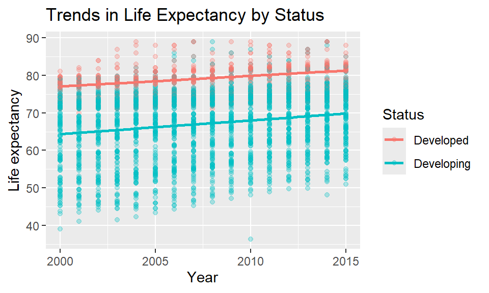

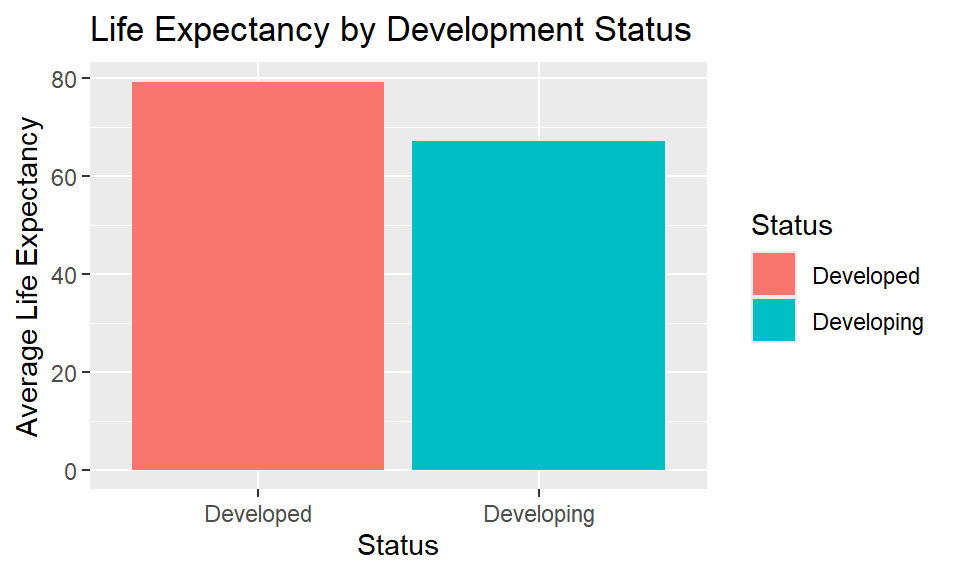

The Scatter plot illustrates the trend in life expectancy from 2000 to 2015, stratified by development status. Each point represents a country-year observation, and the trend lines summarize the linear progression of life expectancy over time. The plot demonstrates a consistent increase in life expectancy for both developed and developing countries, with developed countries maintaining a higher baseline throughout the observed period.

The second plot presents a bar chart comparing the average life expectancy between developed and developing countries. The chart clearly shows that developed countries have a substantially higher average life expectancy compared to their developing counterparts. This highlights ongoing disparities in global health outcomes, likely influenced by differences in healthcare systems, economic development, and social determinants of health.

# The Random Intercept

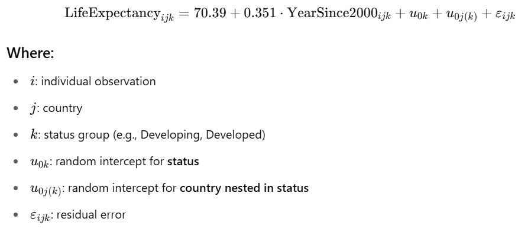

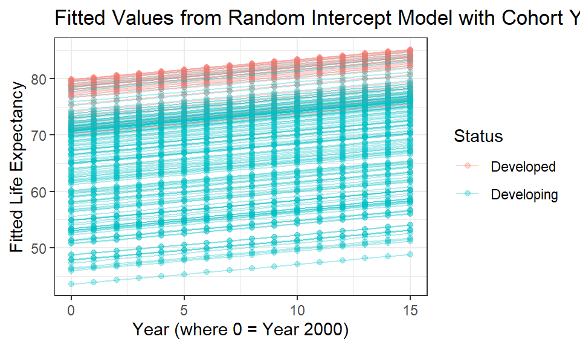

#### The Interpretation :

This mixed-effects model estimates life expectancy as a function of time since the year 2000, while accounting for the nested structure of the data. The fixed effects indicate that the average baseline life expectancy in the year 2000 is 70.39 years. Additionally, for each year after 2000, life expectancy increases by 0.351 years on average.

The model includes two levels of random effects. A random intercept for development status allows each group (e.g., developed or developing countries) to have its own baseline life expectancy. In addition, a nested random intercept for country within each status group accounts for country-specific deviations within those development categories.

# The Random Intercept and Random Slope.

This is a two-level linear mixed-effects model with a random intercept and random slope for time (Year_since2000) at the country level, estimating life expectancy based on country status and time while accounting for within-country variation over time and allowing both baseline life expectancy and its rate of change to vary between countries.

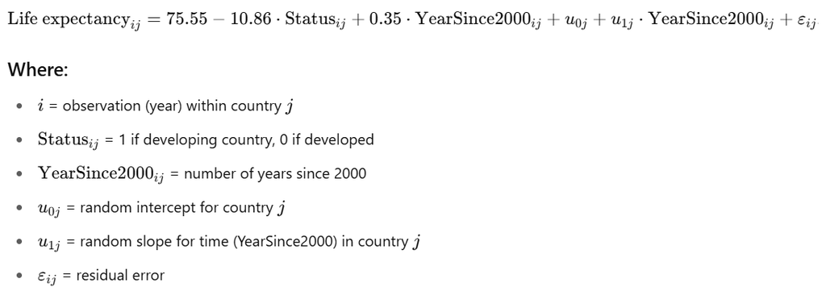

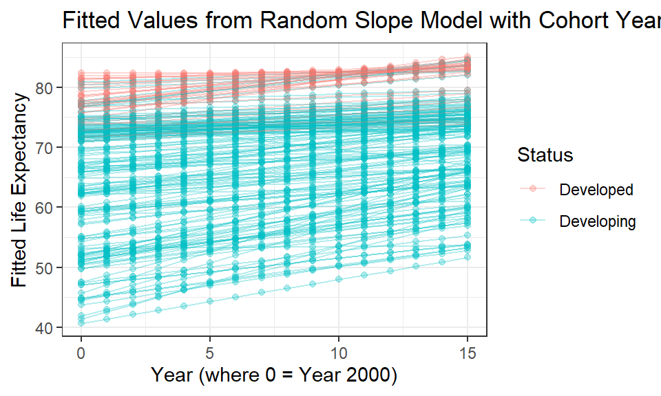

The figure displays fitted life expectancy values from a random slope model, which allows both intercepts and slopes to vary by country. The model adjusts for development status and time (years since 2000). Compared to the random intercept model, this approach captures not only differences in baseline life expectancy but also variation in growth rates across countries. The fitted trajectories show greater flexibility, highlighting country-specific trends in life expectancy over time.

The interpretation :

This mixed-effects model estimates life expectancy as a function of development status, time since the year 2000, and country-specific random effects. According to the fixed effects, developed countries had an estimated baseline life expectancy of 75.55 years in the year 2000. In contrast, developing countries had a significantly lower life expectancy at baseline, with an average reduction of 10.86 years compared to developed countries.

The model also shows that life expectancy increases over time, with each additional year since 2000 associated with a 0.35-year increase in life expectancy on average. To account for variability across countries, the model includes random intercepts and random slopes. The random intercept allows each country to have a different starting level of life expectancy, while the random slope permits each country to have its own rate of change over time.

# Powered By:

Group 3

[figure not shown]

## References

1. Geospatial Health Data: Modelling and Visualization with R-INLA and Shiny, Flexdashboard by Moraga. Paula 2023
2. GitHub Link : git@github.com:omaralfaruqi/AdvancedstatisticalanalysisGroup3.git